# Clase 3: Análisis de varianza y prueba de correlación

[figure not shown]

### Contenido

Parte de la bibliografía utilizada en esta clase:

[Statistics For Biologists](https://books.google.hn/books/about/Statistics_for_Biologists.html?id=McqWIFQzGioC&redir_esc=y)

[Statistics in R for Biodiversity Conservation](https://www.researchgate.net/publication/353286861_Statistics_in_R_for_Biodiversity_Conservation)

García-Berthou, 2001

[Testing for normality in regression models: mistakes abound (but may not matter](https://doi.org/10.1098/rsos.241904)

[Checking for normality and homogeneity of variance](https://mailman.stat.ethz.ch/pipermail/r-help/2010-January/223547.html)

#### Distribucion Normal

La distribución normal es una distribución de probabilidad continua que se utiliza comúnmente en el análisis de datos. Esta distribución es simétrica y tiene una forma de campana, con un pico en el centro y colas que se extienden hacia los valores extremos.

Para los ejercicios de esta clase, utilizaremos la base de datos `delomys.csv`

```r
delomys <- read.csv("data/delomys.csv")
```

```r
library(knitr)
kable(head(delomys))
```

| observation | genus | binomial | body_mass | body_length | age | sex | longitude | latitude | status |
| --- | --- | --- | --- | --- | --- | --- | --- | --- | --- |
| 27526 | Delomys | Delomys dorsalis | 50.5 | 259 | adult | female | -48.22950 | -24.20256 | alive |
| 27528 | Delomys | Delomys dorsalis | 79.0 | 223 | adult | female | -48.22950 | -24.20256 | alive |
| 27529 | Delomys | Delomys dorsalis | 57.0 | 206 | adult | female | -48.22950 | -24.20256 | alive |
| 27530 | Delomys | Delomys dorsalis | 71.0 | 229 | adult | male | -48.22950 | -24.20256 | alive |
| 27533 | Delomys | Delomys dorsalis | 56.0 | 105 | adult | male | -50.39215 | -29.40807 | alive |
| 27534 | Delomys | Delomys dorsalis | 50.0 | 118 | adult | male | -50.39215 | -29.40807 | dead |

Como se puede observar, la base de datos `delomys` presenta varias variables. Si queremos saber si alguna variable en específico presenta una distribución normal, podemos utilizar la prueba de Shapiro o realizar un gráfico cuartil-cuartil.

**Prueba de shapiro**

Es importante tener en cuenta que la prueba de normalidad de Shapiro no es infalible y puede arrojar resultados incorrectos si el tamaño de la muestra es pequeño. Por lo general, se recomienda un tamaño de muestra de al menos 30 para utilizar la prueba de Shapiro de manera fiable. Además, esta prueba puede ser sensible a los valores extremos o anómalos en los datos, por lo que puede ser necesario eliminarlos antes de realizarla.

```r
shapiro.test(delomys$body_mass)
```

```
##
##  Shapiro-Wilk normality test
##
## data:  delomys$body_mass
## W = 0.99506, p-value = 4.33e-05
```

`Es importante aplicar la prueba de normalidad para cada categoría de la variable categórica que se esté estudiando en un análisis de varianza (ANOVA). Esto se debe a que el ANOVA asume que las distribuciones de las poblaciones de las diferentes categorías son normales. Si las distribuciones no cumplen con este supuesto, los resultados del ANOVA pueden no ser válidos. Por lo tanto, antes de realizar el ANOVA, es fundamental verificar la normalidad de los datos en cada grupo para asegurar la fiabilidad de las conclusiones obtenidas.`

```r
shapiro.test(subset(delomys, binomial == "Delomys dorsalis")$body_mass)
```

```
##
##  Shapiro-Wilk normality test
##
## data:  subset(delomys, binomial == "Delomys dorsalis")$body_mass
## W = 0.9962, p-value = 0.01279
```

```r
shapiro.test(subset(delomys, binomial == "Delomys sublineatus")$body_mass)
```

```
##
##  Shapiro-Wilk normality test
##
## data:  subset(delomys, binomial == "Delomys sublineatus")$body_mass
## W = 0.98561, p-value = 2.71e-05
```

Un gráfico de cuartil-cuartil, también conocido como gráfico Q-Q, es una herramienta gráfica utilizada para evaluar si un conjunto de datos sigue una distribución específica. En el caso de una distribución normal, se esperaría que los datos se ajusten a una línea recta en el gráfico.

```r
library(car)
```

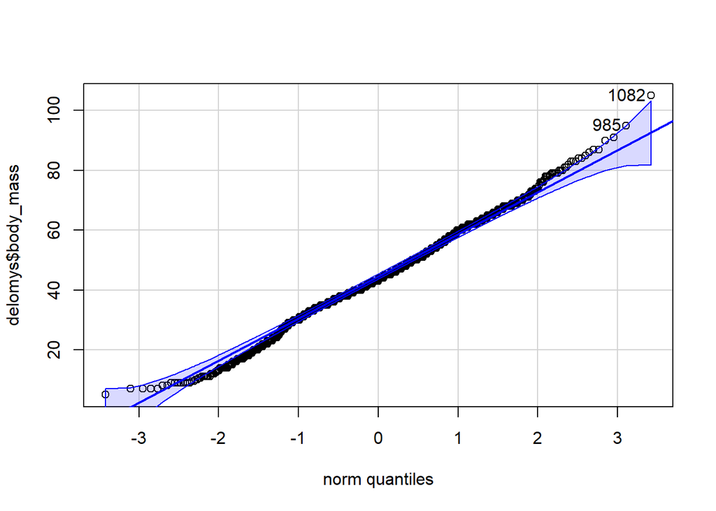

```
## [1] 1082  985
```

```r
qqPlot(delomys$body_mass)
```

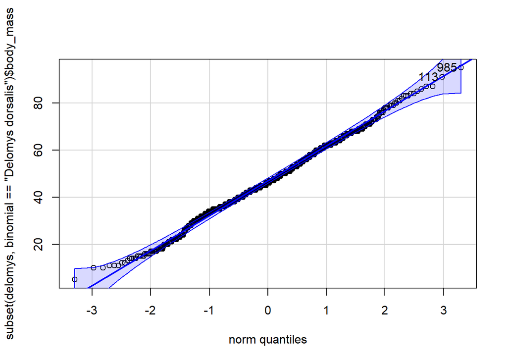

```
## [1] 985 113
```

```r
qqPlot(subset(delomys, binomial == "Delomys dorsalis")$body_mass)
```

Es importante tener en cuenta que el gráfico de cuartil-cuartil es solo una herramienta visual y no proporciona una medida cuantitativa de la normalidad de los datos. Para obtener una medida cuantitativa, se puede utilizar una prueba estadística como la prueba de Shapiro.

#### Prueba de Homogeneidad

La homogeneidad de varianzas es otro supuesto importante en muchas pruebas estadísticas. Para visualizar la homogeneidad de varianzas en una variable categórica, se puede utilizar un gráfico de caja. Sin embargo, un gráfico de dispersión es más adecuado para visualizar la homogeneidad en variables numéricas.

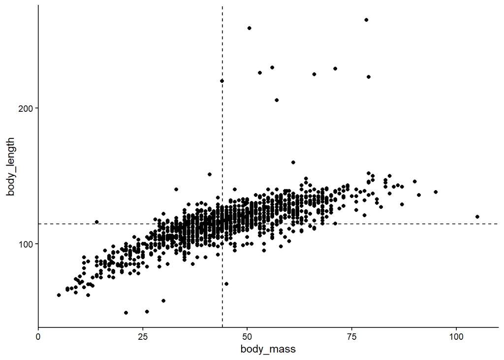

```r
library(ggplot2)

ggplot(data= delomys, aes(x= body_mass, y= body_length)) +
  geom_point()+
  geom_hline(yintercept = 114.701, linetype = "dashed")+
  geom_vline(xintercept = 44.06215, linetype = "dashed")+
  theme_classic()
```

Existen varias pruebas estadísticas para evaluar la homogeneidad de varianzas, como la prueba de Bartlett, la prueba F y la prueba de Levene.

```r
car::leveneTest(body_mass ~ binomial, data = delomys)
```

```
## Levene's Test for Homogeneity of Variance (center = median)
##         Df F value Pr(>F)
## group    1   1.912 0.1669
##       1583
```

```r
library(agricolae)

bartlett.test(body_mass ~ binomial, data = delomys)
```

```
##
##  Bartlett test of homogeneity of variances
##
## data:  body_mass by binomial
## Bartlett's K-squared = 0.19124, df = 1, p-value = 0.6619
```

#### Análisis de varianza

El análisis de varianza (ANOVA) es una técnica estadística utilizada para evaluar si hay diferencias significativas entre dos o más grupos en una variable. Es comúnmente empleada para comparar los resultados de diferentes tratamientos o grupos de estudio en un experimento.

##### ANOVA de una vía

El análisis de varianza (ANOVA) de una vía es una técnica estadística utilizada para evaluar si hay diferencias significativas entre dos o más grupos en una sola variable. Se emplea cuando se tienen dos o más grupos y se desea evaluar si existen diferencias significativas en una sola medida o variable.

```r
table(delomys$status)
```

```
##
## alive  dead
##  1451   134
```

```r
ANOVA_status <- aov(body_mass ~ status, data= delomys)
summary(ANOVA_status)
```

```
##               Df Sum Sq Mean Sq F value Pr(>F)
## status         1     39   38.62   0.174  0.677
## Residuals   1583 351416  221.99
```

Para verificar que el ANOVA se ajusta adecuadamente a los datos, es necesario evaluar la normalidad de los residuales del modelo. Los residuales representan el error del modelo estadístico, es decir, la diferencia entre los valores observados y los valores predichos. Se espera que estos residuales sigan una distribución normal centrada alrededor de cero.

Estos supuestos pueden validarse mediante diferentes paquetes en R; entre las opciones disponibles se encuentran DHARMa y performance, los cuales permiten evaluar de manera integral el comportamiento de los residuales.

```r
library(DHARMa)
modelo <- aov(body_mass ~ status, data= delomys)

sim_res <- simulateResiduals(modelo)
```

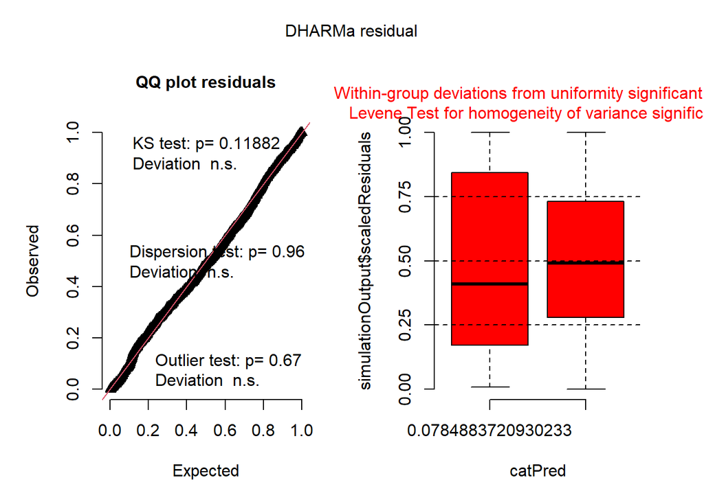

```r
plot(sim_res)
```

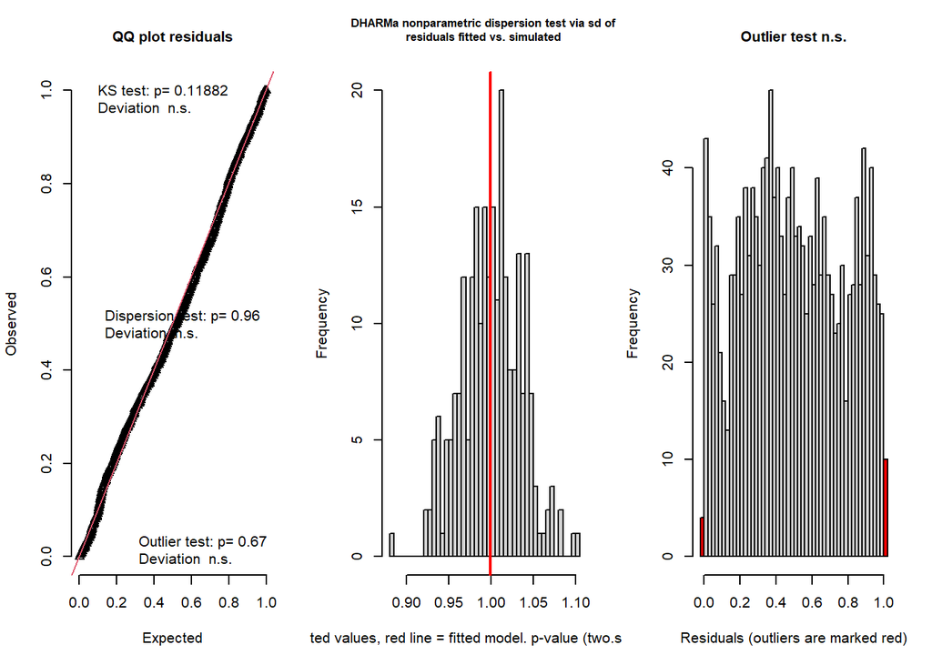

```
## $uniformity
##
##  Asymptotic one-sample Kolmogorov-Smirnov test
##
## data:  simulationOutput$scaledResiduals
## D = 0.029842, p-value = 0.1188
## alternative hypothesis: two-sided
##
##
## $dispersion
##
##  DHARMa nonparametric dispersion test via sd of residuals fitted vs.
##  simulated
##
## data:  simulationOutput
## dispersion = 0.99929, p-value = 0.96
## alternative hypothesis: two.sided
##
##
## $outliers
##
##  DHARMa outlier test based on exact binomial test with approximate
##  expectations
##
## data:  simulationOutput
## outliers at both margin(s) = 14, observations = 1585, p-value = 0.67
## alternative hypothesis: true probability of success is not equal to 0.007968127
## 95 percent confidence interval:
##  0.00483715 0.01477558
## sample estimates:
## frequency of outliers (expected: 0.00796812749003984 )
##                                            0.008832808
```

```r
testResiduals(sim_res)
```

```r
summary(modelo)
```

```
##               Df Sum Sq Mean Sq F value Pr(>F)
## status         1     39   38.62   0.174  0.677
## Residuals   1583 351416  221.99
```

La interpretación se basa en el estadístico F y su correspondiente valor p. El valor F representa la relación entre la variabilidad entre grupos y la variabilidad dentro de los grupos; valores altos de F indican que la variación entre grupos es mayor que la variación interna, lo que sugiere posibles diferencias entre las medias. Sin embargo, la decisión estadística se fundamenta en el valor p: si este es menor que el nivel de significancia establecido (por ejemplo, $\alpha$ = 0.05), se rechaza la hipótesis nula, concluyendo que existen diferencias significativas entre los grupos. En cambio, si el valor p es mayor que $\alpha$, no se rechaza la hipótesis nula, indicando que no hay evidencia suficiente para afirmar que las medias difieren.

Ahora que hemos intrepretados los resultados, podemos graficar utilizando ggeffects.

```r
library(ggeffects)

ggpredict(modelo, terms = "status")
```

```
## Some of the focal terms are of type `character`. This may lead to
##   unexpected results. It is recommended to convert these variables to
##   factors before fitting the model.
##   The following variables are of type character: `status`
```

```
## # Predicted values of body_mass
##
## status | Predicted |       95% CI
## ---------------------------------
## alive  |     44.11 | 43.34, 44.88
## dead   |     43.55 | 41.02, 46.07
```

```
## Some of the focal terms are of type `character`. This may lead to
##   unexpected results. It is recommended to convert these variables to
##   factors before fitting the model.
##   The following variables are of type character: `status`
```

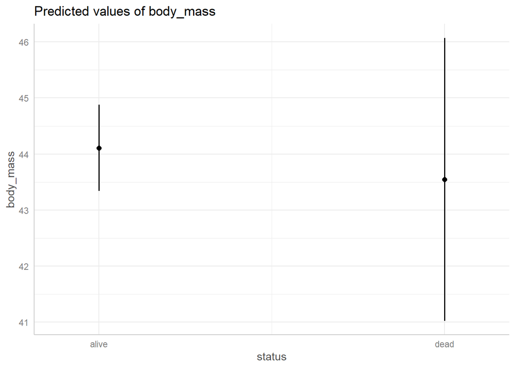

```r
plot(ggpredict(modelo, terms = "status"))
```

##### ANOVA de dos vías

El análisis de varianza (ANOVA) de dos vías es un método estadístico utilizado para comparar las diferencias entre dos o más grupos en una medida de interés. Se llama “ANOVA de dos vías” porque examina dos factores a la vez, cada uno de los cuales puede tener varios niveles o categorías.

```r
table(delomys$status, delomys$sex)
```

```
##
##         female male
##   alive    721  727
##   dead      64   68
```

```r
ANOVA_status_sex <- aov(body_mass ~ status + sex, data= delomys)
summary(ANOVA_status_sex)
```

```
##               Df Sum Sq Mean Sq F value   Pr(>F)
## status         1     14    14.5   0.066 0.797544
## sex            1   3065  3064.9  13.949 0.000194 ***
## Residuals   1577 346489   219.7
## ---
## Signif. codes:  0 '***' 0.001 '**' 0.01 '*' 0.05 '.' 0.1 ' ' 1
## 5 observations deleted due to missingness
```

##### MANOVA

El análisis multivariado de varianza (MANOVA) es un método estadístico utilizado para comparar las diferencias entre dos o más grupos en múltiples medidas al mismo tiempo. A diferencia del análisis de varianza (ANOVA), que se emplea para comparar diferencias entre grupos en una sola medida, el MANOVA se utiliza para comparar diferencias en varias medidas simultáneamente.

```r
delomys_manova <- manova(cbind(body_mass, body_length) ~ sex + status, data = delomys)

summary(delomys_manova)
```

```
##             Df   Pillai approx F num Df den Df    Pr(>F)
## sex          1 0.010151   8.0808      2   1576 0.0003224 ***
## status       1 0.012816  10.2302      2   1576 3.852e-05 ***
## Residuals 1577
## ---
## Signif. codes:  0 '***' 0.001 '**' 0.01 '*' 0.05 '.' 0.1 ' ' 1
```

##### ANCOVA

El análisis de covarianza (ANCOVA) es un método estadístico utilizado para comparar las diferencias entre dos o más grupos en una medida de interés, teniendo en cuenta el efecto de una o más variables covariables. Una variable covariable es aquella que puede afectar el resultado de interés y que se mide o observa al mismo tiempo que dicho resultado.

```r
delomys_ancova <- Anova(lm(body_mass ~ sex + status + body_length, data = delomys))

delomys_ancova
```

```
## Anova Table (Type II tests)
##
## Response: body_mass
##             Sum Sq   Df   F value    Pr(>F)
## sex            192    1    1.9586 0.1618613
## status        1229    1   12.5320 0.0004117 ***
## body_length 191881    1 1955.9345 < 2.2e-16 ***
## Residuals   154609 1576
## ---
## Signif. codes:  0 '***' 0.001 '**' 0.01 '*' 0.05 '.' 0.1 ' ' 1
```

#### Análisis de correlación

El análisis de correlación es una técnica estadística utilizada para determinar si hay una relación entre dos variables. Esta relación se puede medir utilizando el coeficiente de correlación, que puede variar entre -1 y 1. Un coeficiente de correlación cercano a 1 indica una correlación positiva fuerte, lo que significa que, a medida que una de las variables aumenta, la otra también aumenta de manera predecible. Un coeficiente de correlación cercano a -1 indica una correlación negativa fuerte, lo que significa que, a medida que una de las variables aumenta, la otra disminuye de manera predecible. Un coeficiente de correlación cercano a 0 indica una correlación débil o nula entre las variables.

**Prueba de correlación de pearson**

```r
cor.test(delomys$body_mass, delomys$body_length)
```

```
##
##  Pearson's product-moment correlation
##
## data:  delomys$body_mass and delomys$body_length
## t = 44.463, df = 1583, p-value < 2.2e-16
## alternative hypothesis: true correlation is not equal to 0
## 95 percent confidence interval:
##  0.7224776 0.7663251
## sample estimates:
##       cor
## 0.7452058
```

**Prueba de correlación de spearman**

```r
cor.test(delomys$body_mass, delomys$body_length, method = "spearman")
```

```
##
##  Spearman's rank correlation rho
##
## data:  delomys$body_mass and delomys$body_length
## S = 133498504, p-value < 2.2e-16
## alternative hypothesis: true rho is not equal to 0
## sample estimates:
##       rho
## 0.7988407
```

**Grafico de correlacion**

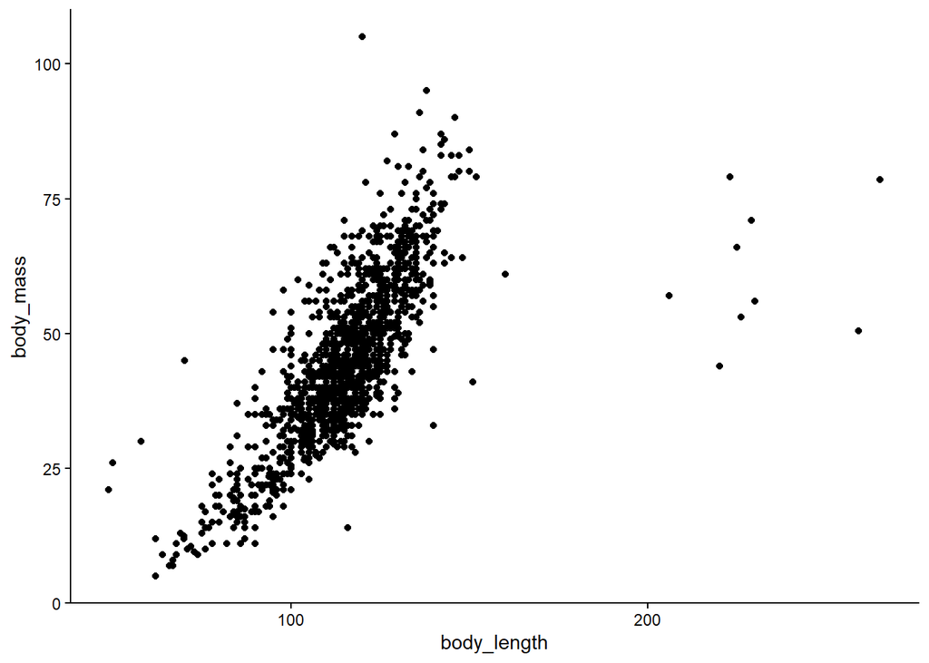

```r
library(ggplot2)

ggplot(data= delomys, aes(x =body_length, y= body_mass))+
  geom_point()+
  theme_classic()
```

#### Ejercicio

1. Investigar para qué se utiliza y cómo se aplica la prueba T de Student.
2. Investigar para qué se utiliza y cómo se aplica la prueba de Kruskal-Wallis.
3. Realizar la prueba de correlación utilizando la base de datos `Barn owls`

```r
owl <- read.table(file = "https://www.dropbox.com/s/0zpy65cr9ml47b6/owl.txt?dl=1",
                  header = TRUE, dec= ".", stringsAsFactors = T)
```

El conjunto de datos de las Barn owls (Tyto alba) proviene del estudio de [Charter et al. (2018)](https://nsojournals.onlinelibrary.wiley.com/doi/epdf/10.1111/jav.01770), quienes investigaron el comportamiento parasitario de crías de lechuzas en Israel. Se observó que algunas crías de lechuza dejaban su propio nido y se mudaban a un nido vecino, donde luego eran alimentadas por, o robaban comida de, sus nuevos “padres adoptivos”. El objetivo de este estudio fue comprender el impacto del cambio de nido en las crías de estos padres adoptivos. El estudio mostró que 12 crías de lechuza abandonaron su nido de origen y se trasladaron a 9 nidos anfitriones de un total de 111 nidos monitoreados. Los datos de estos 9 nidos “parasitados” fueron investigados en mayor profundidad.

Los objetivos del estudio fueron:

Evaluar si había una asociación entre la edad de las crías parasitarias de lechuza y las crías anfitrionas.

Evaluar si había una asociación entre la edad de las crías anfitrionas cuando se detectó a una cría parasitaria de lechuza en el nido anfitrión y el número de crías anfitrionas que lograron emplumar exitosamente desde ese nido.

El dataframe comprende 9 observaciones de 5 variables. Cada fila en el dataframe representa un nido anfitrión de lechuza separado al cual una cría de otro nido se trasladó. La variable hosbox es un código único para identificar el nido anfitrión. El número de días después del primero de enero en que los huevos de la cría parasitaria de lechuza (layday_para) y de la cría anfitriona (layday_host) fueron puestos, la edad del nido (age_para) y el número de crías de lechuza que emplumaron del nido parasitado (fled_host) son todas variables continuas.

Enviar los scripts a `david.murillo@hnbiology.org`